# What is happening to my nearby stores? The own- and cross-effect of a radical store transformation on existing customers

Converted from PDF `Breugelmans-RadicalStoreTransformation-2024-JAMS.pdf` · 22 pages · anchors: page `#pN`, block `#pN-bK`

Page 1

### Vol.:(0123456789) 1 3

Journal of the Academy of Marketing Science (2024) 52:217–238 https://doi.org/10.1007/s11747-023-00946-2

#### **ORIGINAL EMPIRICAL RESEARCH**

### **What is happening to my nearby stores? The own‑ and cross‑effect of a radical store transformation on existing customers**

**Els Breugelmans<sup>1</sup> · Marleen Hermans<sup>2</sup> · Manfred Krafft<sup>3,4</sup> · Mirja Kroschke<sup>3,5</sup> · Felix Lehmkuhle<sup>3</sup> · Murali Mantrala<sup>6</sup>**

Received: 3 March 2021 / Accepted: 4 May 2023 / Published online: 30 May 2023 © Academy of Marketing Science 2023, corrected publication 2023

**Abstract** Brick-and-mortar grocery retailers that undertake major format changes often do so in a staggered rollout and radically transform just one store at a time. This approach begs two questions: What effects does a radical store transformation have on existing customers’ sales at the transformed store (own-effect) and at the chain’s nearby untransformed stores (crosseffect)? Do the effects vary with customer characteristics? These questions are investigated using a quasi-field experiment of a staggered radical store transformation of a German retailer. Conventional wisdom would predict cannibalization of nearby untransformed stores’ sales. However, applying our proposed theoretical framework shows, for this empirical case, a negative own- but a positive cross-effect on existing customers. Further, existing customers who had a greater preference for and shopped more at the old format are most likely to migrate. Thus, nearby untransformed stores can help retain existing customers who may get turned off by a radical store transformation.

**Keywords** Quasi-field experiment · Major format change · Own- and cross-effect · Sales performance · Store choice

To remain competitive and grow, many brick-and-mortar grocery retail chains introduce new store formats that look radically different from their old store formats. They generally do so in an attempt to provide enhanced shopping experiences for customers and thereby achieve increased engagement, sales revenue, and growth. Between 2016 and 2019 for example, the German hypermarket retailer Real transformed four of its stores into a so-called *Markthalle*, a setting that resembles an indoor marketplace where customers can find a broader assortment of fresh, authentic, and regional products accompanied

by a much higher level of personal service than in Real’s old format stores (Macridi, 2018). Thus, *Markthalle’s* value proposition is radically different from that of longstanding Real stores. Similarly, the Belgian retailer Delhaize radically transformed nine of its 140 stores in 2018: this “totally new concept which completely changes the classic store design” focused on an enlarged assortment of fresh, organic, and local products, on high-quality grab-and-go meals, and it had a heightened level of service (Retail Times, 2018).

Oftentimes, such store format changes involve radically transforming existing stores in their current locations as finding equally favorable new spots for new stores is very challenging in most developed countries. Furthermore, as a practical matter, the large investments entailed in such radical transformations usually allow only staggered transformations of stores across the chain. Given such gradual rollout, it is often the case that only one store in a region gets transformed, and then coexists with nearby untransformed stores that hold the old format for months, years, or even permanently.

While attracting new customers to the retail chain is one of the objectives when introducing major format changes, the fact that transformations usually happen at current locations makes the impact on existing customers of considerable interest and importance to the chain’s management too. Also, extant marketing literature acknowledges that retaining

Andrew Petersen served as Area Editor for this article.

* Els Breugelmans els.breugelmans@kuleuven.be

1 Faculty of Economics and Business (FEB), KU Leuven, Leuven, Belgium

2 Institute for Management Research, Radboud University Nijmegen, Nijmegen, The Netherlands

3 Chair of Marketing Management, University of Muenster, Münster, Germany

4 University of Auckland, Auckland, New Zealand

5 Otto GmbH & Co KG, Hamburg, Germany

6 KU School of Business, University of Kansas, Lawrence, KS, USA

Page 2

218 Journal of the Academy of Marketing Science (2024) 52:217–238

1 3

loyal customers has substantial profit benefits (Gupta et al., 2004; Reichheld, 1993; Reinartz & Kumar, 2002). These arguments combined with the fact that radical store transformations happen in a staggered strategy, where one store in a region is transformed and other nearby stores are not, begs the question of how *existing customers* at *both the transformed and the nearby untransformed stores* of the chain are impacted by *a radical store transformation*.

With this study, we investigate two research questions: (1) What effects does a radical store transformation have on existing customers at the transformed store (own-effect) and at the chain’s nearby untransformed stores (cross-effect)? And (2) How do the own- and cross-effect vary with customer characteristics? The answer to the first question will be helpful for understanding the impact of a radical store transformation on existing customers at the transformed store and nearby untransformed stores of the chain, and can guide the selection of locations of stores to be transformed as the radical format change strategy is rolled out. Insights into the second question will enable more effective marketing to existing customers of staggered store transformations that convert the retailer (temporarily or permanently) from a single to a dual (transformed & untransformed) format chain.

We conduct the first empirical investigation of these questions utilizing data from a geographical cluster of three stores of a major retail chain in a metropolitan area of Germany that radically transformed one (focal) store while retaining the old format in the two nearby stores. The radical store transformation was enormous in scope: it included a *remodeling* of the servicescape, a *repositioning* that was aimed at providing a finer shopper experience relative to the lower-priced, no-frills format it used to have (and that was retained in the nearby stores), and a *rebranding* with a new logo and slogan for the transformed store (Zhao et al., 2018). Consequently, the store transformation resulted in a radically different value proposition and store identity. The focal store was the first to be transformed to the radically new format by the retail chain, and it entailed considerable investments. The chain’s management team was keen to understand and assess the impact of the radical store transformation on existing customers at both the transformed and the chain’s nearby untransformed stores in the cluster. In this research, we define existing customers of the retail chain as those who are members of the retailer’s loyalty program and have had ample shopping experience at and are more engaged with the retail chain before the store transformation took place.

Conventional wisdom (also shared by the management at the collaborating retail chain in this research) would predict that the revamped store format would appeal to existing customers and even pull some existing customers away from the old, untransformed stores to the transformed one. That is, the transformed store would cannibalize sales at nearby untransformed stores, by triggering a migration of existing customers

from those stores to the newly transformed one. This would lead to a positive effect of the store transformation on existing customers at the transformed store (i.e., a positive *owneffect*) and a negative effect on existing customers at the chain’s nearby untransformed stores (i.e., a negative *cross-effect*).

However, managers’ expectations about the effects of a radical store transformation on existing customers can suffer from a “rosy view” bias (Hult et al., 2017). This leads them to overestimate positive perceptions their customers hold: given all the investments made, existing customers “should” be attracted and respond positively to the transformed store. Yet, many managers do not accurately understand drivers of customers’ perceptions of the firm’s offer (Hult et al., 2017). Specifically, they may overlook existing theory pertaining to shoppers’ store choices (e.g., Bell et al., 1998 and further expanded by Tang et al., 2001) which delineates how a combination of store attributes contribute to individual customers’ perceived fixed and variable costs and benefits of shopping at a particular store, which shape their overall preferences and choices of where to shop.

In this research, we develop a framework that is based on the extant shopping utility theory and apply it to our empirical case of the first staggered radical store transformation of a German retailer. Applying the theoretical framework to our empirical case suggests effects of the radical store transformation on existing customers that run counter to the above-mentioned conventional wisdom. Specifically, based on our proposed theoretical framework, we hypothesize that the radical store transformation that we consider has a *negative own-effect* on existing customers at the transformed store and a *positive cross-effect* at nearby untransformed stores. Thus, for our empirical case, a radical store transformation is expected to lead to migration of existing customers *away* from the transformed store to the untransformed ones. This seemingly counterintuitive expectation has not been theoretically proposed or empirically examined previously.

We apply the framework to our empirical case in two studies that feature before–after with control group quasiexperimental methods. In Study 1, we focus on existing customers’ aggregate sales at the transformed store and nearby untransformed stores. Contrary to conventional wisdom, but in line with our theory-based hypothesis, we find a negative own- and a positive cross-effect. In Study 2, we take a disaggregate view and analyze the individual-level shopping behavior of existing customers. In line with our hypotheses, significant migration occurs among existing customers away from the transformed store and toward nearby untransformed ones, even more among those who, *prior* to the format change, (a) shopped more frequently and spent more at the transformed store; and (b) displayed more sensitivity to promotions and private labels, two store attributes that had been scaled back in the new store format. Thus, at least in our research context, a chain’s nearby untransformed

Page 3

219 Journal of the Academy of Marketing Science (2024) 52:217–238

1 3

stores in the same geographical cluster effectively help retain some existing customers who perceive a loss in their total shopping utility following the radical store transformation.

In an era where ‘enhancing customer experience’ is the catchphrase for survival and success in retailing circles, the present research offers a novel empirical counterexample that has important implications for managers of retail chains pursuing similar *radical* transformations of their stores. Our research findings caution retailers in similar contexts making similar moves to not take their existing customers for granted. It suggests that a staggered rather than a simultaneous approach to radical store transformations is not simply a practical response to budget constraints; it might be strategically effective for retaining existing customers. These findings were certainly eye-opening for the management of the collaborating retail chain, inducing them to make important adjustments to the chain’s transformation rollout strategy. Our findings suggest that managers’ “rosy view” bias can lead them to concentrate on an anticipated increase in perceived value among existing customers and makes them ignore accompanying reductions in their fixed or variable utility. While the specifics of our findings may be unique to the case we investigate, the theorization is applicable to other store transformations and can help predict *other* patterns of the likely own- and cross-effect (see Stremersch et al., 2023, why context-specific studies such as ours are valuable).

In the next section, we briefly review related literature to highlight our contributions. After we describe our research setting, we develop our conceptual framework and hypotheses. We then describe the empirical methodology and detail our findings from Studies 1 and 2, which use, respectively, aggregate store-level sales data and disaggregate individual customers’ shopping behavior data. We close with a discussion of the findings, managerial implications, and directions for further research.

#### **Positioning of our research relative to past literature**

Previous research in the domain of store transformations is sparse. We categorize the few existing studies into three relevant categories, related to (1) store remodeling, (2) store repositioning, and (3) store format changes (see Table 1).

The three papers in the first category focus on the effects of remodeling the servicescape (defined as non-human elements of the environment, such as ambience, layout, signage, and décor, in which service encounters occur; Bitner 1992) on the performance of the focal store. Their findings suggest that servicescape remodeling enhances focal store performance (Brueggen et al., 2011; Dagger & Danaher, 2014), especially if the remodeling has a substantial

magnitude (Ferraro et al., 2017), but the impact disappears over time (Brueggen et al., 2011; Dagger & Danaher, 2014). Yet servicescape remodeling, even an extensive one, entails less change than a radical store format change that effectively changes the store’s positioning and identity, along with its servicescape (see Web Appendix A for a beforeafter visualization of the store format change we investigate). Further, no servicescape remodeling papers have investigated the nature or magnitude of effects of a remodeled store on nearby, non-remodeled stores, nor do they consider existing customers’ responses, as determined by customer characteristics.

In addition, we offer a more nuanced view of some previous findings and recommendations that have appeared in this remodeling literature. For example, Dagger and Danaher (2014) find increased sales in general but also specify that sales of new customers are significantly higher than those of existing customers. In turn, they recommend that retail managers could concentrate on new customers, who offer stronger sales growth potential and faster revisit rates. Our research indicates that the retention of existing customers needs close attention as well. By showing that a radical store transformation can risk alienating existing customers who prefer the old format, and maintaining untransformed stores nearby can help to retain them, we provide more nuanced insights. We also provide suggestions for identifying existing customers who are at risk and should be targeted with appropriate communications and promotions to ensure their retention by the chain as a whole.

A second category of related research focuses on store repositioning, that might occur as a result of an ownership change following the acquisition of a store by another chain or when the retailer instigates major changes in positioning, for instance via assortment and/or pricing changes. For example, van Lin and Gijsbrechts (2014) study customers’ tendencies to revisit a repositioned store that has been acquired by another chain. In their case, the entire chain is under new ownership. Customers can no longer stay loyal to the previous chain at that location, and they tend to be very aware that the store’s image and identity are likely to differ under the new owner. Consequently, our finding of interest, i.e., migration of existing customers from the radically transformed to old format stores of the same chain, is not a subject of their study. Corstjens and Doyle (1989) instead investigate the impact of significant changes to the merchandise portfolio on a fashion store’s profitability; Sarantopoulos et al. (2019) assess the impact of a complement- versus substitutebased product assortment reorganization. These studies focus on the impact of the repositioning on the one focal store where the repositioning occurs, without considering nearby untransformed stores, or without investigating heterogeneity across consumers. Furthermore, changes to the

Page 4

220 Journal of the Academy of Marketing Science (2024) 52:217–238

1 3

**Table 1** Literature review

a Focal store refers to the store that was remodeled, repositioned, converted, or radically transformed

Research focus Investigated store(s) Outcome Moderation

Performance at store level Performance at customer level Customer differences

Brueggen et al. (2011) Store remodeling Focal storea Average spending, Store

traffic Planned vs. spontaneous;

Group vs. single

Dagger and Danaher (2014) Store remodeling Focal store Sales New vs. existing

Ferraro et al. (2017) Store remodeling Focal store Sales

van Lin and Gijsbrechts

(2014) Store repositioning (store

ownership change) Focal store Store choice Loyalty

Sarantopoulos et al. (2019) Store repositioning (assort-

ment reorganization) Focal store Average basket size (units &

amount) Involvement; Shopping goal

specifity

Corstjens and Doyle (1989) Store repositioning (merchan-

dise portfolio) Focal store Category sales

Hwang and Park (2016) Store format change (open-

ing/conversion to Walmart

supercenter as a new format)

(1) Focal store &

(2) Nearby stores, also with

new format (other Walmart

supercenters)

Spending

Store choice Average per-visit

expenditures

This paper **Transformation to radical**

#### **label shoppers; Conveni-**

#### **ence shoppers; Fresh food**

#### **shoppers; Healthy product**

#### **shoppers**

Page 5

221 Journal of the Academy of Marketing Science (2024) 52:217–238

1 3

price or assortment positioning are much narrower than a radical store transformation.

Lastly, to the best of our knowledge, only Hwang and Park (2016) provide research insights into the (own- and) cross-effect of major store format changes, by investigating the effect of transforming Walmart discount stores into supercenters on consumer behavior at other, existing Walmart supercenters. They found a positive own- and a negative cross-effect, implying cannibalization when a similar-format store gets introduced in a neighborhood where other stores with the same format already exist. These authors, however, do not examine effects of a radically new format on nearby stores *that keep the old store format* as we do in our research. Nor do they explicitly examine individual-level characteristics to find existing customers who are more or less likely to shift to nearby untransformed stores.

#### **Research setting and design**

We first describe our research setting in more depth so we can immediately apply the conceptual framework and hypotheses that follow to the case at hand. Our research setting is a major grocery retail chain that operates more than 250 hypermarkets across Germany. Its assortment includes various food (e.g., fresh fruits and vegetables, meat and fish, dairy products, canned food) and non-food (e.g., drugstore items, electronics) categories. In 2016, the retailer transformed one of its stores to offer customers an enhanced shopping experience; as the manager in charge of the store transformation rollout explained in an interview with the authors, the transformation aimed to “increase the quality of time that [customers] spend in a store because of other aspects that [they] can have over there, basically to enjoy a nice meal, to be kind of indulged by the presentation of the fresh food assortment…. [The transformed store] should have a kind of event character.” The transformation (see Web Appendix A) of the approximately 11,300 square meter store included a *remodeling* of the servicescape, a *repositioning* based on significant changes in store attributes like assortment breadth, depth, and pricing, and a *rebranding* with a new logo and slogan for the transformed store (Zhao et al., 2018). Reflecting the enormous scale and budget needed for this radical transformation, its opening was preceded by a 32-week construction period, from spring 2016 until fall 2016, including 6 weeks in which the store was completely closed.

The transformation resulted in a radically different value proposition and shifted the focal store from a lower-priced, no-frills positioning to an upscaled, experience-based one. The following changes illustrate this: store space devoted to fresh food more than doubled, from about 1,085 square meters to 2,350 square meters; the average price level for fresh food went up by 27% (from €3.46 to €4.40, due to the introduction of higher-priced fresh food items, though

previously stocked lower-priced items remained in the assortment); and the number of full-time employees providing service in the store significantly increased (by about 30%). With the transformation, the retailer aimed to enhance its service level (new focus on gastronomy, conveniently packaged goods, better-skilled service employees) and emphasize the freshness and quality of its food products (larger fresh food assortment; more locally produced and organic items in the assortment). Existing customers were basically exposed to a radically different store identity, where several of the store attributes like the low price and no-frills setting that were stressed in the old store format’s position faded.

In the same area as the transformed store (within a 10-km radius) are two other stores of the same retail chain that remained untransformed, i.e., continued to follow the old store format. The selected 10-km radius reflects the typical trade area for stores in Europe (van Lin & Gijsbrechts, 2019), and the retail chain’s management agreed about defining these three proximate stores as the geographical cluster of interest.<sup>1</sup> The two untransformed stores are substantial in size (about 8,700 m² and 6,900 m²). Before the transformation, marketing activities such as price (changes), promotions, and advertising campaigns were identical across all stores; the old store format targeted the same customer segment and was very similar in assortment breadth. The decision to transform only one store in this geographical cluster was deliberate, largely reflecting budget constraints, and it effectively created a dual (transformed & untransformed) store format cluster. Management mentioned in an interview that there was “no immediate reaction from the competitors’ side” to the transformation, and our systematic search of national and regional newspapers (Nexis Uni database) confirmed the lack of major competitive responses during the observation window in the focal region.

The company provided data from its customer loyalty program database. This loyalty program enables customers to collect points, redeemable for discounts and other service-related benefits (e.g., free delivery when ordering online). Thereby, this retailer gathers detailed data about loyalty program members’ individual shopping behavior and sociodemographics. No changes in loyalty program membership requirements occurred for any store including the transformed one and consumers had no need to switch to nearby untransformed stores to keep using their loyalty card. With the program data, we perform a quasi-field experimental analysis of the own- and cross-effect on existing customers’ sales and shopping behavior at the transformed and the chain’s nearby untransformed stores.

1 The closest next (untransformed) store is located about 20 km away from the transformed store, so it is not “nearby”, as was confirmed by the retail chain’s management.

Page 6

222 Journal of the Academy of Marketing Science (2024) 52:217–238

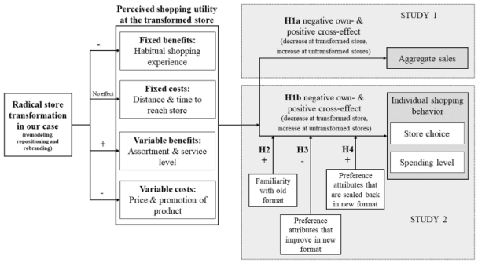

NOTE: figure/graphic rendered as an image from the PDF; its content is not machine-readable text. Caption (if any) follows as the next block.

1 3

#### **Theoretical framework**

Grocery shoppers develop habitual purchase behaviors and use choice heuristics or decision cues to simplify their decision processes (Hoyer, 1984; Hoyer & Brown, 1990). However, disruptive changes can lead consumers to reassess shopping options and modify established shopping behavior (Janakiraman et al., 2006; Melis et al., 2016; Rhee & Bell, 2002). To predict how existing customers might adapt their behavior in response to a radical store transformation, which is a disruptive change, we turn to the well-accepted perceived shopping utility theory that was initiated by Bell et al. (1998) and expanded by Tang et al. (2001). Bell et al. (1998) argue that store choice depends on the perceived *costs* involved in shopping; Tang et al. (2001) add perceived shopping *benefits* as important components of the total shopping utility too. Work of, for instance, Gijsbrechts et al. (2008) and Vroegrijk et al. (2013) applied this theory. We too apply Tang et al.’s (2001) expanded shopping utility framework to derive the effects of a radical store transformation on existing customers.

The spirit of the shopping utility framework is that consumers’ store choices are based on a comparison of the perceived total shopping utility of each store, such that they choose to shop at the store where the total utility is positive and highest among all available stores. Total utility equals the sum of fixed and variable utility, where fixed utility is independent of the volume purchased, while variable utility varies with the shopping basket and amount spent (Bell et al., 1998; Briesch et al., 2009; Gijsbrechts et al., 2008; Tang et al., 2001).

Fixed utility reflects the difference between fixed benefits and fixed costs (Tang et al., 2001). A shopper’s habitual shopping experience, stemming from store loyalty

and implying a higher degree of familiarity with the store layout, assortment, and product locations, is an important contributor to fixed benefits derived from a store. The fixed costs relate to distance and time needed to reach the store. Fixed utility of a particular store increases for customers who shop there habitually (larger fixed benefits) and who live close to or can reach a store quickly (lower fixed costs).

Variable utility is the difference between variable benefits and variable costs (Tang et al., 2001). Following Gijsbrechts et al. (2008) and Vroegrijk et al. (2013), we link marketing mix elements to variable utility components. Specifically, in line with these papers, variable benefits result from the store’s assortment and service level, and variable costs rise or fall with product prices paid. Variable utility of a particular store increases when the store offers a more appealing assortment and higher service level (larger variable benefits) and/or lower prices and more attractive price promotions (lower variable costs).

Applying the above shopping utility theory to our specific research setting described previously, Fig. 1 displays the conceptual framework for our investigation of the effects of one radical store transformation (involving remodeling, repositioning, and rebranding) on more engaged existing customers, while other nearby stores retain the old store format, and competing retailers do not vigorously react. We reiterate that the hypothesized effects indicated in Fig. 1 and detailed below are specific to our research setting. In the Future Research section, we elucidate how the underlying theorization can be applied to other store transformation cases and discuss boundary conditions to our expectations (and findings).

Considering that the radical transformation that we investigate was implemented at the current location, the fixed costs of shopping at that location for existing customers do

**Fig. 1** Conceptual framework

Page 7

223 Journal of the Academy of Marketing Science (2024) 52:217–238

1 3

not change. But the radical transformation likely alters other components that constitute total utility, including customers’ fixed benefits and variable utility (variable benefits and costs) of shopping at the transformed store.

Regarding fixed benefits, a radical store transformation is expected to significantly disrupt habitual shopping experiences. For instance, even if the transformation improves the servicescape, a radically new store plan raises existing customers’ store navigation costs. Also changes in product location and assortment can pose additional processing costs for existing customers due to information overload, increased cognitive effort, choice uncertainty and choice difficulty that lead to choice avoidance (Sethuraman et al., 2022). For the radical store transformation that we investigate, we expect that existing customers’ fixed utility from shopping at the transformed store decreases, because the substantial disruption of habitual shopping experience lowers fixed benefits while fixed costs remain the same.

Regarding existing customers’ variable utility, variable benefits or costs can shift depending on the new store format. In our case, the radical store transformation involved a shift from a lower-priced, no-frills positioning to a more upscaled, experience-based positioning. This repositioning likely improves customers’ perceptions of variable benefits, reflecting the heightened service level and deeper food assortment. Yet existing customers might also perceive higher variable costs because the store no longer stressed the price and no-frills focus in its positioning which, at least perceptually, led to a higher-priced and less promotion-oriented store image. Most existing customers preferred shopping in the old store format (otherwise they would have patronized the competition, rather than our focal store) and hence they have, via their past store choice, demonstrated a certain preference for store attributes of the old store format that were scaled back in the radical store transformation. Therefore, we expect that the variable utility of the transformed store, for *most existing* customers, decreases more than it increases.

If, as we have argued, both fixed and variable utility decrease for most existing customers, then those who previously derived a higher total utility from shopping at the nowtransformed store than at the chain’s nearby untransformed stores may perceive the situation has reversed after the radical store transformation. As a result, existing customers may migrate (partly or entirely) to the nearby untransformed stores where they now derive greater shopping utility than at the transformed store.

Applying this rationale to our first research question on the own- and cross-effect of a radical store transformation on aggregate sales (Study 1), we predict:

**H1a** A radical store transformation decreases existing

customers’ sales at the transformed store (negative

own-effect) and increases existing customers’ sales at the chain’s nearby untransformed stores (positive cross-effect).

In the next four hypotheses, we shift to a disaggregate shopping behavior analysis (Study 2). The first of these predictions parallels the aggregate-level hypothesis (H1a), but decomposes the main effects of the radical store transformation on existing customers’ sales into effects on individuallevel purchase behavior, specifically, their *likelihood to shop* and their (conditional) *spending level*.<sup>2</sup> Consistent with the theoretical reasoning underlying H1a, we expect that the negative own- and the positive cross-effect is due to a reduction in existing customers’ likelihood to shop and/or spending at the transformed store, accompanied by an increase in these measures at the chain’s nearby untransformed stores. Thus, we hypothesize:

**H1b** A radical store transformation decreases existing

customers’ likelihood to shop and/or spending at the transformed store (negative own-effect) and increases existing customers’ likelihood to shop and/or spending at the chain’s nearby untransformed stores (positive cross-effect).

Regarding our second research question, we develop hypotheses pertaining to differences among existing customers who are more or less likely to migrate away from the transformed store to the untransformed stores. These hypotheses bear on how familiar a customer is with the old store environment (which affects fixed benefits and variable utility) and how sensitive the customer is to the store attributes that the store transformation altered (which affects variable benefits and variable costs).

In terms of familiarity, an intuitive thought would be that existing customers who are more familiar with the old store format might remain after the transformation while less engaged customers migrate to nearby untransformed stores. This would be in line with the long tradition in the literature that has shown that stronger relationships (captured here as familiarity, based on more visits and larger baskets) imply a higher preference and buffer against migration tendencies (Maslow, 1937). Yet our conceptual framework based on shopping utility theory instead implies that existing customers with greater familiarity suffer a stronger disruption of their habitual shopping behavior at the transformed store (e.g., due to higher store navigation costs), resulting in lower fixed benefits.

2 Aggregate sales = number of visits * spending per visit by existing customers. The number of visits is the consequence of their ‘Likelihood to shop’ which captures whether an existing customer will visit a store in that week, and the (conditional) ‘spending’ which captures the weekly expenditures given a visit.

Page 8

224 Journal of the Academy of Marketing Science (2024) 52:217–238

1 3

Moreover, their past behavior in terms of greater shopping frequency and spending at the focal store indicates a greater liking for store attributes (variable utility) of the old store format. A radical transformation may thus also have a stronger negative impact on the variable utility at the transformed store for existing customers who are more familiar with the old store format. Hence:

**H2** The negative own- and positive cross-effect of a radi-

cal store transformation (as hypothesized in H1b) are greater for existing customers who are more familiar with the focal store before the transformation.

Next, whether a radical store transformation leads to a stronger increase or decrease in existing customers’ variable utility depends on existing customers’ preferences for store attributes perceived to be enhanced or scaled back in the transformation. Specifically, the store attributes that were enhanced by the radical transformation that we investigate included the provision of much deeper assortments of fresh, healthy, and convenience products and enhanced service levels. Vroegrijk et al. (2013) linked the marketing mix assortment and service elements to the variable benefits. Customers with strong preferences for the improved product assortments and services (i.e., those that prefer fresh, healthy, and convenience products) would perceive higher variable benefits and derive greater variable utility at the transformed store. As long as this increase in variable utility exceeds any perceived reduction in fixed utility, these existing customers are less likely to reduce their purchases at the transformed store. So:

**H3** The negative own- and positive cross-effect of a radi-

cal store transformation (as hypothesized in H1b) are smaller for existing customers who prefer store attributes that are improved in the transformed store.

Because of the move to a more upscaled, experience-based positioning, there are also store attributes that were scaled back by the radical store transformation, suggesting at least perceptually, a less favorable price (promotion) image. These changes very likely make the transformed store less appealing, at least perceptually, for existing customers displaying price (promotion) sensitivity such as those who tend to buy on promotion or those who tend to buy private labels (Ailawadi et al., 2001). These consumers are more likely to experience a decrease in variable utility leading to the following hypothesis:

**H4** The negative own- and positive cross-effect of a radi-

cal store transformation (as hypothesized in H1b) are greater for existing customers who prefer store attributes that are scaled back in the transformed store.

We reiterate that the hypotheses detailed above are derived from applying the proposed shopping utility based framework to our specific empirical case under investigation. In the next section, we assess whether the hypotheses can be confirmed in our empirical analyses.

#### **Empirical analyses**

We first investigate whether the radical store transformation of our empirical case generates a negative own- and a positive cross-effect on existing customers’ *sales* at the aggregate (store) level (Study 1, addressing H1a). Then in Study 2, we examine how it affects existing customers’ *shopping behavior* (addressing H1b) and, more specifically, which customer characteristics strengthen or weaken the hypothesized main effect (addressing H2-H4).

#### **Study 1: Own‑ and cross‑effect of a radical transformation on existing customers’ sales**

To investigate the own- and cross-effect of the radical transformation of one of the chain’s stores in a geographical cluster on existing customers’ sales, we employ aggregate weekly sales data of existing customers from all three stores in the cluster. These data encompass 79 pre-construction weeks, 26 construction weeks, 6 closure weeks, and 85 weeks after the reopening of the transformed store (196 weeks total). We define existing customers as loyalty program members who shopped at least once in a store of the chain using their loyalty card, before the reopening of the transformed store (these are more engaged existing customers).

**Matching procedure** To isolate the impact of the transformation on existing customers’ sales in the transformed store and the nearby untransformed stores, we must control for other effects that might influence sales, such as general evolutions and trends. Therefore, we use matching algorithms to link each of the three stores in our geographical cluster with a control store in another part of the country where no store transformation occurred (e.g., Avery et al., 2012). Web Appendix B provides a detailed description of the matching procedure, which relies on variables that likely inform the company’s decision to impose a store format change for the focal store and in a particular region, and on variables with more general impacts on store performance. To select these matching variables, we followed research by Ailawadi et al. (2010) and Avery et al. (2012) and also obtained managers’ input. Web Appendix B (Fig. B.1 and Table B.2) reveals the proximity in the magnitude and movement of sales across stores in the treatment zone and their control counterparts in the preconstruction period, confirming the matching quality.

Page 9

225 Journal of the Academy of Marketing Science (2024) 52:217–238

1 3

**Model‑free evidence** Web Appendix B (Fig. B.1 and Table B.2) also contains the descriptive statistics for the comparisons of the transformed store, the nearby untransformed stores and the geographical cluster with its control store(s) or cluster. The transformed store’s existing customers’ sales relative to corresponding sales in its control store appear to be declining, especially in the first months after reopening; the nearby untransformed stores’ existing customers’ sales increased relative to corresponding sales in their respective control stores. For the geographical cluster as a whole, we see some tendency of diminished sales, especially in the months after the reopening.

**Model specification** To test H1a, we apply the following model to the aggregate sales of existing customers (e.g., Avery et al., 2012; Datta et al., 2018):

where the dependent variable *SalesTreatmentStoret – Sales- ControlStoret* measures the difference in existing customers’ sales in week *t* (ranging from week 1 to 196) between the treatment and control store for each matched pair of stores. We specify Eq. 1 three times and thus estimate three models with the following differences as dependent variables: (1) the weekly sales of the transformed store versus its control; (2) the combined weekly sales of the two nearby untransformed stores versus the sum of their control stores’ sales,<sup>3</sup> and (3) the combined sales of all three treatment stores versus their three control stores’ sales. The first two models help establish the negative own- and positive cross-effect as per H1a; the last model provides insights into the net impact of the transformation for the whole cluster.

In line with Avery et al. (2012), our main independent variable of interest is an *Afteropendummy*, a step dummy variable that represents the opening of the transformed store, such that it equals 0 before the reopening and 1 thereafter. This variable captures overall sales changes resulting from the transformation that take place after the reopening, and remain for the duration of our empirical study. A significant negative effect in the transformed store model (Model 1), accompanied by a significant positive effect in the nearby untransformed stores model (Model 2), would offer support for H1a.

With the *Afteropenweeks* variable, we gauge the number of weeks since the store reopening, equal to 1–84, starting one week after the reopening (it is 0 in the weeks before and the week of the reopening). This variable captures potential

(1)

*SalesTreatmentStoret* −*SalesControlStoret* = *훽*0

+ *훽*1*Afteropendummyt* + *훽*2*Afteropenweekst* + *훽*3*Constructiont* + *훽*4*Closuret* + *훽*5*FirstFourWeekst* + *휀t*.

growth effects resulting from the transformation. We also control for *Construction* and *Closure* periods (two pulse dummy variables that indicate the weeks in which the focal store was under construction or closed, respectively) and for the *FirstFourWeeks* (pulse dummy that equals 1 in the first four weeks after the opening of the transformed store, to capture aspects like media attention; Breugelmans & Liu- Thompkins, 2017).<sup>4</sup> Finally, εt is an idiosyncratic error term.

**Results** Table 2 presents the model parameter estimates of the full model (T = Transformed store, UT = nearby UnTransformed stores, and CLUS = geographical CLUSter). (The side-by-side build-up of Eq. 1 is reported in Web Appendix B, Table B.3.) These results reveal that the radical store transformation led to diminished sales of existing customers in the transformed store ( β<sup>T</sup>

For the geographical cluster as a whole, we find diminished sales of existing customers, according to the significant coefficient of the *Afteropendummy* ( β<sup>CLUS</sup>

1 = -215,727.0, *p* < .01). That is, sales losses in the transformed store were not fully compensated for by nearby untransformed stores’ gains. Over time, however, a positive coefficient emerged for the *Afteropenweeks* variable for the cluster ( β<sup>CLUS</sup>

2 = 2,749.5, *p* < .01), driven by the recovery in the transformed store. The loss in sales of existing customers in the cluster following the format change appears to be offset by positive effects over time.<sup>5</sup>

Among the control variables, we observe, as expected, positive effects for the first four-week period for the transformed

3 We summed the sales of the two nearby untransformed stores, to keep the analyses and findings tractable and because we are not interested in differential effects across these two nearby stores.

4 The main results remain robust to a different operationalization that accounts for the overlap of the first four weeks, such that we respecify the *Afteropendummy* variable to equal 1 only after the first four weeks following opening and 0 before, and the *Afteropenweeks* variable to take values of 1–80 after the first four weeks following opening and 0 before. The model is also robust when we use ln(*Afteropenweeks*) and when we add two dummies that equal 1 in the first or last two weeks of the construction period, respectively. Also accounting for possible sales changes due to press exposure (dummy variable, equals 1 in the weeks before the reopening when the format change was mentioned in the press, 7 total) did not change the main results. The press exposure dummy variable was not significant. 5 To depict how the transformation effect varies over time, we ran a model with 84 time dummies instead of the *Afteropendummy* and the *Afteropenweeks* variables. We plot the coefficients in Web Appendix B, Fig. B.2. They substantiate our findings.

Page 10

226 Journal of the Academy of Marketing Science (2024) 52:217–238

1 3

store and the cluster in general. In the construction and closure periods, we observe negative effects on existing customers’ sales at the transformed store (both), a positive effect at the nearby untransformed stores (closure only; nonsignificant for construction), and negative effects for the cluster as a whole (both). Existing customers reduced their shopping at the focal store during construction but were not motivated yet to switch to the nearby untransformed stores. The net overall negative effect on the cluster suggests that sales losses at the transformed store during closure are only partly compensated for by sales increases at nearby untransformed stores.

**Discussion** While conventional wisdom would lead to managers expecting that a major store format change will draw existing customers away from nearby untransformed stores to the transformed one (cannibalization), our quasi-experimental analysis confirms migration in the opposite direction, as hypothesized. The transformed store that we study suffers a drop in sales of existing customers following the radical store transformation (negative own-effect), but nearby untransformed stores experience a sales lift (positive cross-effect). The increase in sales enjoyed by nearby untransformed stores persists over time, while the transformed store experiences a gradual recovery (positive growth effect) that can turn the initial losses into gains over time. Overall, our research suggests that at least some existing customers shift their shopping to nearby untransformed stores, but who are these customers? To better explain migration from the transformed to nearby untransformed stores, we consider customer characteristics, with more disaggregate analyses at the customer level.

**Study 2: Own‑ and cross‑effect of a radical transformation on existing customers’ shopping behavior and the moderating effects of customer characteristics**

Sales that a customer generates at a store can be decomposed into the customer’s likelihood to shop and weekly spending

level (in euro) at the store, conditional on store choice. To gain a clearer understanding of how a radical store transformation affects store choice and the (conditional) spending, at the transformed and nearby untransformed stores, and how these effects are moderated by customer characteristics, we focus on the individual customer level in Study 2. The loyalty program data we use are specified at the household level; individual customers tend to buy for all members of the household when shopping. We use the term “customer” in the conceptualization but revert to “household” in the empirical analyses.

**Data** We use loyalty program members’ weekly household level purchase data at the transformed store and nearby untransformed stores, covering the same weeks as in Study 1: 79 preconstruction weeks, 26 construction weeks, 6 closure weeks, and 85 weeks after reopening the transformed store (196 weeks in total). Furthermore, other descriptors of the loyalty program members, collected by the retail chain, enable us to operationalize several customer characteristics of interest. To operationalize the moderators and control variables, we rely on data from an initialization period, spanning the 27 weeks that preceded the 52-week before-transformation period. We then estimate the model on the remaining 169 weeks, after excluding the 27 initialization weeks.

For Study 2, we only focus on those existing loyalty program members who have a minimum of four purchases during the 52-week before-transformation period plus a minimum of two purchases in the 27-week initialization period. This selection helps ensure stable model estimations and access to information about the moderating customer characteristics, which is available only for customers who reach this minimum purchase frequency level.<sup>6</sup> We excluded

**Table 2** Results: Study 1

* *p* < .05, ** *p* < .01. T = transformed store, UT = untransformed store, CLUS = geographical cluster

Notes: All figures have been multiplied by an unspecified number, for confidentiality reasons

[output not shown]

NOTE: table converted from PDF layout to HTML text; cell boundaries are reconstructed. See PDF if exact alignment matters.

6 The requirement of a minimum of four purchases per year is supported by company practice; some data are available only for customers who reach this minimum. We additionally selected households with a minimum of two purchases in the initialization period, or about half of the before period.

Page 11

227 Journal of the Academy of Marketing Science (2024) 52:217–238

1 3

business shoppers, defined by average per basket spending above €250, and the small proportion of shoppers (0.24%) who shopped in both treatment and control zones. We did not impose any criteria pertaining to the after-transformation period, so our analyses capture all transformation effects, including losses from existing customers who left the chain.

**Customer characteristics** With the conceptual framework in Fig. 1, we note three sets of customer characteristics that may moderate the effect of the store transformation on shopping behavior. From a theoretical viewpoint, and given unaltered fixed costs (time and effort required to reach the transformed store do not change), the customer characteristics of interest are those that reflect changes in fixed benefits or variable utility (benefits and costs). These characteristics include: customers’ past purchase behavior, which captures their degree of familiarity with shopping at the transformed store (linked to fixed benefits and variable utility); customers’ assortment- and service-related preferences (linked to variable benefits); and customers’ sensitivity to price (promotions) (linked to variable costs).

We measure the *degree of familiarity* as purchase frequency and average basket size at the transformed store in the initialization period, in line with extant literature that relates familiarity to prior store visits and spending (van Heerde et al., 2008). To capture customers’ *assortment- and service-related preferences* (the store attributes that got enhanced), we use three buyer-related variables: fresh food, healthy product, and convenience buyers. Both fresh food and healthy product buyers should be more inclined to appreciate the improved assortment after the transformation (respectively, freshly produced foods and healthy, regional, and organic products). Convenience buyers instead are more prone to eat in and should appreciate the expanded benefits of easy dining-in services. *Sensitivity to price (promotions)* (which are the store attributes that got scaled back) is captured by two variables: the sensitivity customers have toward promotions and their preference for (often lower-priced) private-label products (Ailawadi et al., 2001). Customers who tend to buy private-label brands are described as value seekers, who prefer good quality but do not want to pay excessive price premiums (Ailawadi & Harlam, 2004).

We created the customer characteristics using behavioral data gathered via the loyalty card, if available (familiarity, fresh food buyer, promotion sensitivity); otherwise, we relied on the customer relationship management (CRM) classification used by the retailer (healthy product buyer, convenience buyer, and private-label buyer). This CRM classification is based on a sophisticated segmentation analysis of loyalty program members’ purchase behavior. The outcomes are segments that classify customers on the basis of their purchase behavior and the categories and product types they buy. The

classification is thus objective, in the sense that it is based on purchases made by consumers, not on consumers’ own judgments or perceptions. The segmentation adopted furthermore is non-fuzzy, in that there is no overlap in the CRM classification segments to which households are assigned.

**Matching procedure** To isolate the impact of the store format change from other effects, we compare the shopping behavior of households in our treatment zone with the shopping behavior of households in a control zone. The control zone is similar to our treatment zone, in that it has a cluster of three (untransformed) stores, located approximately the same distance from one another as in the treatment zone. These stores are not the same as those that served as control stores for our store-level investigation of the effects on aggregate sales (Study 1). Rather than seeking control stores as similar as possible to each of the stores in the treatment zone, in Study 2, our focus is on households, so we match at the household level, looking for similar shopping behavior in a geographically similar control zone. Web Appendix C provides a detailed description of this matching procedure.

For each of the households in the treatment zone, we found a ‘twin’ household in the control zone that is similar in shopping profile and the distribution of purchases across the different stores of the chain in the geographical cluster in the initialization period. The matching quality was confirmed as our matching variables did not significantly differ between treatment and control households; the Hoteling T-squared test also considerably improved (see Table C.2, Web Appendix C). In addition, the maximum absolute standardized mean difference of 0.0287 is below the threshold of 0.25 suggested by Avery et al. (2012).

**Model specification** To test whether households change their store choice and spending decisions, and explore how such outcomes differ across customer characteristics, we simultaneously estimate a store choice and spending (euro, conditional on choice) model using a maximum likelihood procedure (see Danaher & Dagger 2013). We perform two model estimations, one with store choice and spending at the transformed store and one with store choice and spending at nearby untransformed stores. For the nearby untransformed stores model, we use a pooled store choice model (equal to 1 when at least one of the two nearby untransformed stores is visited in any particular week, 0 otherwise) and take the sum of spending at the untransformed stores as the second-stage dependent variable.<sup>7</sup>

7 As in Study 1, we summed spending in the two nearby untransformed stores. The percentage of observations with visits to both nearby stores in the same week is very small, just 0.41% of all observations.

Page 12

228 Journal of the Academy of Marketing Science (2024) 52:217–238

1 3

We adopt a difference-in-differences approach to compare the before- and after-transformation differences in the likelihood of store choice and spending at the store of interest for a household located in the treatment zone, versus the same differences of its twin household in the control zone. The first component of this model determines if household *i* chooses to shop at the transformed store or the nearby untransformed stores (in the transformed store or nearby untransformed stores model, respectively) in week *t* (from 1 to 169). The store choice decision (*StoreChoice*it) is described by a binomial Probit model:

where *StoreChoice*<sup>∗</sup>

*it*<sup>is a latent variable capturing the attrac</sup>tiveness to household *i* of making a purchase in week *t* in the store under consideration (transformed or nearby untransformed stores). It is modeled by the following specification:

where *Treati* is a dummy variable that equals 1 for household *i* that shops in the treatment zone and 0 for those of the control zone; *Aftert* is a dummy variable that equals 1 if week *t* is in the period after the opening of the transformed store and 0 otherwise. The coefficient *β3* is the difference-in-differences response and reflects the amount by which the probability that household *i* visits the store under consideration in week *t* changes from the before- to the after-transformation period for treated relative to control households (test of H1b).

Then, to examine whether these effects differ with customer characteristics (test of H2–H4), we include six threeway interactions of the customer characteristic variables with the difference-in-differences response *Treati * Aftert*. We also include the main effects and two-way interactions with *Treati* and *Aftert*, for comprehensiveness (see also Ma et al., 2013). Finally, we control for distance; sociodemographic variables of age, gender, and household size; familiarity with the untransformed stores (in this store choice component of the model, we include purchase frequency at the untransformed store), and time-varying characteristics including the construction period, closure period, first four weeks after reopening period, and a holiday dummy variable. We also include all two- and three-way interactions for these control

(2) *StoreChoiceit* =

{ 1, *if StoreChoice*∗

*it <sup>></sup>*<sup>0</sup> 0, *otherwise* ,

(3)

*StoreChoice*<sup>∗</sup>

+ *훽*2*Aftert* + *훽*3*Treati* ∗*Aftert* + *훽*4*PFreqi*

+ *훽*5*Freshfoodbuyeri* + *훽*6*Healthyproductbuyeri*

+ *훽*7*Conveniencebuyeri* + *훽*8*Promoi*

+ *훽*9*PLbuyeri* +

∑

*훽*10to15*InteractionswithTreati*

+

NOTE: contains mathematical notation; text above is the PDF text layer and symbols may be mis-extracted. Image shows the original.

∑

NOTE: contains mathematical notation; text above is the PDF text layer and symbols may be mis-extracted. Image shows the original.

*훽*16to21*InteractionswithAftert*

+

**equation / math rendering (image)**

NOTE: contains mathematical notation; text above is the PDF text layer and symbols may be mis-extracted. Image shows the original.

∑

**equation / math rendering (image)**

NOTE: contains mathematical notation; text above is the PDF text layer and symbols may be mis-extracted. Image shows the original.

*훽*22to27*InteractionswithTreati* ∗*Aftert*

+

**equation / math rendering (image)**

NOTE: contains mathematical notation; text above is the PDF text layer and symbols may be mis-extracted. Image shows the original.

∑

**equation / math rendering (image)**

NOTE: contains mathematical notation; text above is the PDF text layer and symbols may be mis-extracted. Image shows the original.

*훽*28to73∕74*Controlvariablesi*∕*t* + *휀it*,

variables with *Treati*, *Aftert*, and *Treati * Aftert*.<sup>8</sup> Table 3 contains an overview of the operationalizations.

For the second component of the model, or how much a household *i* spends in week *t* in the store under consideration, contingent on choosing that store, we use a log-normal specification. By taking the logarithm, we reduce skewness and improve the fit by ensuring the variable is more “normally” distributed (Ataman et al., 2010).

where AvBasketi is the average weekly spending at the transformed store in the initialization period (to respect the exclusion criteria). All other explanatory variables are as defined for Eq. 3, except for the control variable that captures familiarity with the untransformed stores; here, we include the average weekly spending at untransformed stores in the initialization period. We allow for a correlation ρ between *εit* and *µit*.

If the signs of the two-way interactions *Treati * Aftert* are negative in the transformed store model (negative own-effect) and positive in the untransformed stores model (positive crosseffect), we find support for H1b, because the likelihood of visiting a store and/or the spending decline in the transformed store while these measures increase in the nearby untransformed stores. For the moderating effects, we look at the signs of the three-way interactions of the customer characteristic variables with *Treati * Aftert*. The negative own- and positive cross-effect weaken if the coefficients of these three-way interactions have a positive effect in the transformed store model and a negative effect in the nearby untransformed stores model. There is a strengthening effect if the coefficients of these three-way interactions have a negative effect in the transformed store model and a positive effect in the nearby untransformed stores model.

**Model‑free evidence** Web Appendix C provides some model-free evidence on the comparison of households in the treatment zone to households in the control zone across

(4)

*Spending*<sup>∗</sup>

*it* <sup>=</sup>*<sup>훿</sup>*<sup>0</sup><sup>+</sup>*<sup>훿</sup>*<sup>1</sup>*<sup>Treat</sup><sup>i</sup>*<sup>+</sup>*<sup>훿</sup>*<sup>2</sup>*<sup>After</sup><sup>t</sup>*

+ *훿*3*Treati* ∗*Aftert* + *훿*4*AvBasketi*

+ *훿*5*Freshfoodbuyeri*

+ *훿*6*Healthyproductbuyeri* + *훿*7*Conveniencebuyeri* + *훿*8*Promoi*

+ *훿*9*PLbuyeri* +

∑

NOTE: contains mathematical notation; text above is the PDF text layer and symbols may be mis-extracted. Image shows the original.

*훿*10to15*Interactions with Treati*

+

**equation / math rendering (image)**

NOTE: contains mathematical notation; text above is the PDF text layer and symbols may be mis-extracted. Image shows the original.

∑

**equation / math rendering (image)**

NOTE: contains mathematical notation; text above is the PDF text layer and symbols may be mis-extracted. Image shows the original.

*훿*16to21*Interactions with Aftert*

+

**equation / math rendering (image)**

NOTE: contains mathematical notation; text above is the PDF text layer and symbols may be mis-extracted. Image shows the original.

∑

**equation / math rendering (image)**

NOTE: contains mathematical notation; text above is the PDF text layer and symbols may be mis-extracted. Image shows the original.

*훿*22to27*Interactions with Treati* ∗*Aftert*

+

**equation / math rendering (image)**

NOTE: contains mathematical notation; text above is the PDF text layer and symbols may be mis-extracted. Image shows the original.

**equation / math rendering (image)**

NOTE: contains mathematical notation; text above is the PDF text layer and symbols may be mis-extracted. Image shows the original.

8 In the transformed store model, sales equal 0 during the closure period, so we cannot estimate the store closure effect for treatment households. Accordingly, the transformed store model contains 73 coefficients, whereas the nearby untransformed stores model has 74 coefficients.

1 3

**Table 3** Operationalization of variables used in Study 2

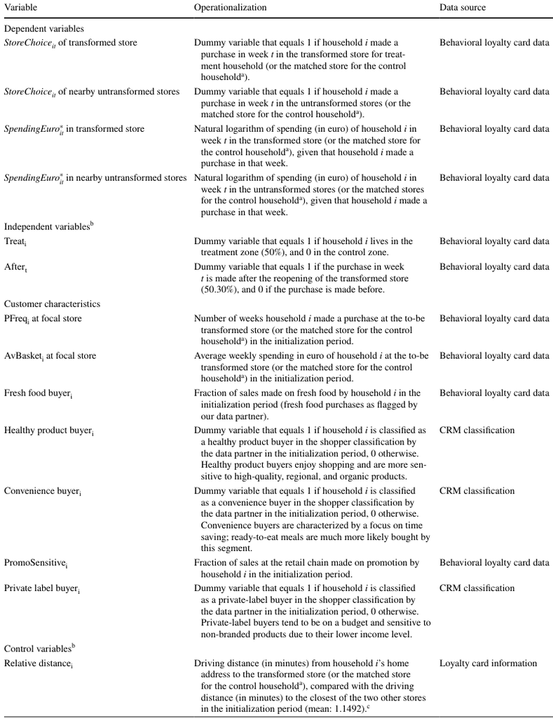

NOTE: complex table shown as an image of the PDF; the text below is a rough machine extraction and may be mis-aligned.

**extracted text (unreliable layout)**

1 3

different periods (Table C.3), on the purchase behavior in the 6-week closure period and subsequent behavior (Fig. C.1), and on the variation across households using histograms of 10 exemplary treatment zone households and their control counterparts (Fig. C.2). These descriptive statistics signal a negative own- and a positive cross-effect in the period after reopening, and point to variation across households.

**Results** Table 4 contains the descriptive statistics and correlations of the dependent variables and customer characteristic moderators (Table C.4 in Web Appendix C shows the full correlation table and the side-by-side build-up of Eqs. 3–4 is in Table C.5). The maximum absolute correlation among independent variables is 0.56 (frequency and basket size at the focal store before transformation, which we do not include together in the model), so multicollinearity is not an issue (Judge et al., 1988). Table 5 presents the model parameter

estimates of the full model. Due to space limitations, we report the coefficients of *Treat*i, *After*t, *Treat*i * *After*t, and the (threeway) interactions of the moderating customer characteristics with the difference-in-differences response. In the model for the transformed store and the one for the nearby untransformed stores, the error correlation between choice and spending is significant (ρT = − 0.069, *p* < .01 and ρUT = − 0.250, *p* < .01), which underscores the importance of a joint estimation procedure. Most main effects of customer characteristics (and control variables) are in the expected direction.<sup>9</sup>

a For the control households, we include the store that matches the shopping pattern allocations of the treatment household, specifically, the control household’s primary, secondary, or tertiary store if the store under consideration is the primary, secondary, or tertiary store for the treatment household (see Web Appendix C).

b We report the descriptive statistics of the independent variables and control variables in brackets; the descriptive statistics of the dependent variables and customer characteristics can be found in Table 4.

c The maximum driving distances is 60 min (for longer distances, a value of 60 is reported). Distance = 60 happens for a small fraction of the households (5.68%). A robustness check showed that excluding households with distance = 60 did not alter any of the substantive findings.

**Table 3** (continued)

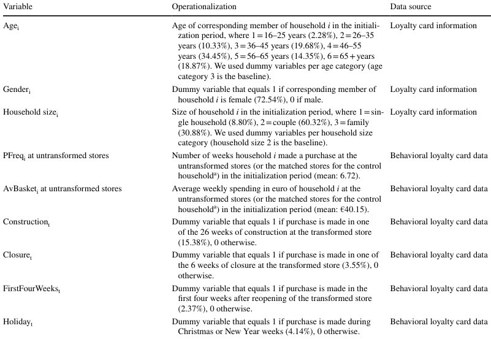

NOTE: complex table shown as an image of the PDF; the text below is a rough machine extraction and may be mis-aligned.

**extracted text (unreliable layout)**

9 The control variables (*Treat*i * *After*t * *RelDistance*i) point to a broadening of the catchment area for the transformed store: Existing customers who live relatively farther away from the transformed store are more likely to visit it, and if they do, they also spend more. For untransformed stores, existing customers who live relatively closer are more likely to visit it, but if they do, they spend less.

1 3

**Table 4** Correlation matrix: Study 2

Notes: T = transformed store, UT = untransformed store

a All continuous variables are mean-centered. The table depicts the descriptive statistics (mean, median, etc.) before mean-centering

b These high correlations are logical, because store visit (store choice = 1) is always accompanied with positive spending and no visit (store choice = 0) means no spending (spending = 0). For

this reason, we use a two-stage model where we simultaneously estimate a store choice and, conditional on choice, a spending model

Store choice

T Store

choice

UT

Spending euro

T Spending euro

UT Purchase

frequency Ta Average

basket size

Ta

Fresh food

buyera Healthy product

buyer Convenience

buyer Promotion

sensitivitya Private label

buyer

Store choice T 1.00 − 0.16 .96b − 0.16 0.58 0.33 0.07 0.02 − 0.01 − 0.04 0.00 Store choice

UT 1.00 − 0.16 .96b − 0.25 − 0.23 0.08 0.01 0.00 − 0.02 0.02

Spending euro

T 1.00 − 0.16 0.59 0.36 0.08 0.03 − 0.01 − 0.05 0.00

Spending euro

UT 1.00 − 0.25 − 0.22 0.09 0.01 0.01 − 0.03 0.01

Purchase fre-

quency Ta 1.00 0.56 0.12 0.03 − 0.01 − 0.07 0.00

Average basket

size Ta 1.00 − 0.02 0.03 0.00 − 0.03 0.00

Fresh food

buyera 1.00 0.18 − 0.06 − 0.13 0.05

Healthy prod-

uct buyer 1.00 − 0.17 − 0.06 − 0.15

Convenience

buyer 1.00 0.01 − 0.17

Promotion

sensitivitya 1.00 0.01

Private label

buyer 1.00

1 3

Because continuous variables are mean-centered, we can interpret the difference-in-differences (*Treat*i * *After*t) coefficients as the effects of the transformation for the average customer. Existing customers decide to shop at the transformed store more frequently ( β<sup>T</sup>

3<sup>= 0.282,</sup>*<sup>p</sup>*<sup>< .01), though when</sup> they do so, they spend less money ( δ<sup>T</sup>

3<sup>= − 0.044,</sup>*<sup>p</sup>*<sup>< .01).</sup> The negative effect that we observed in the aggregate saleslevel analyses thus appears to come from smaller shopping baskets rather than from existing customers reducing their store visit frequency at the transformed store. Turning to the nearby untransformed stores model, we find that, compared with customers in the control zone, existing customers in the treatment zone are more likely to shop at nearby untransformed stores after the transformation ( β<sup>UT</sup>

3<sup>= 0.122,</sup>*<sup>p</sup>*<sup>< .01),</sup> and they also spend more ( δ<sup>UT</sup>

3<sup>= 0.016,</sup>*<sup>p</sup>*<sup>< .01). In line with</sup> H1b, we thus find that existing customers spend less per trip in the transformed store, visit the untransformed store more often, and spend more money in the latter. Yet, in contrast with our expectation, they visit the transformed store more often, so we can only partially confirm H1b.

In support of H2, the coefficients of the three-way interactions with purchase frequency and average basket size (capturing familiarity) go in opposite directions in the transformed versus the nearby untransformed stores model. We observe a more negative effect in the former when customers exhibit greater familiarity with the old store format of the transformed store, as indicated by the significant negative difference-in-differences coefficients of purchase frequency in

the store choice model ( β<sup>T</sup>

22<sup>= − 0.007,</sup>*<sup>p</sup>*<sup>< .01) and of average</sup> basket size in the spending model ( δ<sup>T</sup>

22<sup>= − 0.001,</sup>*<sup>p</sup>*<sup>< .01). At</sup> the same time, we observe positive coefficients for the threeway interactions with familiarity in the untransformed stores model (purchase frequency β<sup>UT</sup>

22<sup>= 0.007,</sup>*<sup>p <</sup>*<sup>.01; average</sup> basket size δ<sup>UT</sup>

22<sup>= 0.0004,</sup>*<sup>p</sup>*<sup>< .01).</sup> We further find that customers who are sensitive to store attributes that were enhanced in the new store format reveal positive effects in the transformed store choice model. Specifically, fresh food buyers ( β<sup>T</sup>

23<sup>= 0.145,</sup>*<sup>p</sup>*<sup>< .01), healthy</sup> product buyers ( β<sup>T</sup>

24<sup>= 0.071,</sup>*<sup>p</sup>*<sup>< .01), and convenience</sup> buyers ( β<sup>T</sup>

25<sup>= 0.048,</sup>*<sup>p</sup>*<sup>< .01) are more likely to shop at the</sup> transformed store after the store transformation. Contingent on store choice, healthy buyers ( δ<sup>T</sup>

24<sup>= 0.036,</sup>*<sup>p</sup>*<sup>< .01)</sup> and convenience buyers ( δ<sup>T</sup>

25<sup>= 0.050,</sup>*<sup>p</sup>*<sup>< .01) even spend</sup> more money in the transformed store. Although fresh food buyers visit the transformed store more often, they lower their spending ( δ<sup>T</sup>

23<sup>= 0.024,</sup>*<sup>p</sup>*<sup>< .05)</sup>

**Table 5** Results and robustness checks: Study 2a

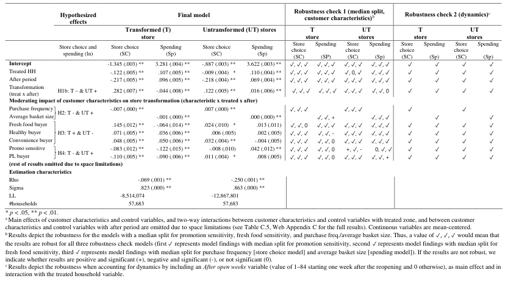

NOTE: complex table shown as an image of the PDF; the text below is a rough machine extraction and may be mis-aligned.

**extracted text (unreliable layout)**

1 3

and convenience buyers ( β<sup>UT</sup>

25<sup>= 0.032,</sup>*<sup>p</sup>*<sup>< .01) are even</sup> *more* likely to shop at nearby untransformed stores, though we find no significant changes in spending ( δ<sup>UT</sup>

23<sup>= 0.013,</sup>*<sup>p</sup>* > .05 and δ<sup>UT</sup>

25<sup>= − 0.004,</sup>*<sup>p</sup>*<sup>> .05, respectively). A possible</sup> explanation could be an image effect of the transformation that makes customers more loyal to the whole chain. We confirm the positive own-effect but cannot confirm the crosseffect expectations, hence we cannot confirm H3.

Finally, customers with a preference for store attributes that got scaled back in the new store format reveal negative effects in the transformed store choice model. Specifically, promotion-sensitive customers and private-label buyers in the treatment zone are more likely to switch away from the transformed store ( β<sup>T</sup>

26<sup>= − 0.083,</sup>*<sup>p</sup>*<sup>< .01 and</sup><sup>β</sup><sup>T</sup> 27<sup>= − 0.110,</sup> *p* < .01, respectively) and spend less money if they visit it ( δ<sup>T</sup>

26 = − 0.122, *p* < .01 and δ<sup>T</sup>

27<sup>= − 0.090</sup>*<sup>p</sup>*<sup>< .01, respectively).</sup> This is in line with our predictions of a negative own-effect. For nearby untransformed stores, promotion-sensitive customers are unaffected in their store choice ( β<sup>UT</sup>

26<sup>= − 0.008,</sup> *p* > .05), but they spend more money at the untransformed stores after the transformation ( δ<sup>UT</sup>

26<sup>= 0.042,</sup>*<sup>p</sup>*<sup>< .01). Private</sup>label buyers are more likely to visit a nearby untransformed store after the store transformation ( β<sup>UT</sup>

27<sup>= 0.011,</sup>*<sup>p</sup>*<sup>< .05)</sup> but do not alter their spending once they visit ( *훿*<sup>UT</sup>

27<sup>= 0.008,</sup> *p* > .05). These significant effects are in line with our predictions of a positive cross-effect. Thus, H4 is supported.

**Robustness checks** To test the robustness of our model to alternative model specifications, we conducted several checks (Table 5),<sup>10</sup> using different operationalizations of our continuous independent variables. Specifically, we applied a median split to the continuous variables (i.e., promotion sensitivity, fresh food buyer, and purchase frequency/average basket size), then repeated the analyses three times, changing one variable at a time. The results are robust, with a few minor exceptions. The continuous variables allow for more variation, so we retained them in our final models. We also allowed for dynamics and replaced the *After* variable with an *After open weeks* variable (equal to 1–84 starting one week after the reopening and 0 otherwise), both as the main effect and in interaction with the treated household variable *Treat*i. Again, our results are robust to this alternative specification. We report the more parsimonious static models, to keep the findings tractable.

**Discussion** The findings from the household-level shopping behavior analyses for our empirical case suggest partial support for the negative own- and the positive crosseffect. While the transformation indeed stimulates existing

customers to shop at the nearby untransformed stores and then, spend more (positive cross-effect), the effects for the transformed store (own-effect) are more mixed. The decrease in existing customers’ sales in the transformed store (found in Study 1) appears to stem from a decrease in their spending level in that store, while they even increase their shopping frequency. These customers seemingly use the transformed store for its ambience, fun, and quick dining-in options. The findings also highlight considerable heterogeneity in customer response to a store transformation. If customers exhibit characteristics that suggest they might perceive lower fixed benefits and lower variable utility (familiarity with the old format) or higher variable costs (price or promotion sensitivity), they will migrate away from the transformed store, but if they have characteristics that suggest they may perceive higher variable benefits (because the new store format improves store attributes they prefer), they are positively affected at the transformed store, as we hypothesized. For these buyers, we also note some positive effects on nearby untransformed stores. This unexpected finding suggests that positive effects for some segments spread to nearby untransformed stores too.

#### **General discussion**

To respond to the challenges in the current retailing landscape, several grocery retail chains across the globe implement radical transformations at current locations. Such radical format changes go beyond the typical store remodelings that have been researched in the past (Brueggen et al., 2011; Dagger & Danaher, 2014; Ferraro et al., 2017; Sarantopoulos et al., 2019), as they also involve a store repositioning (and sometimes a rebranding). These efforts generally aim to keep brickand-mortar stores appealing and fresh, but they also might alienate some of the existing customers, as was the case in our empirical analyses. Radical format changes are expensive, such that most retail chains cannot afford to transform all their stores at once. Our findings suggest they might not want to do so anyway, due to the value of maintaining untransformed stores nearby the transformed store to retain existing customers.

By examining the effects of a radical store transformation on existing customers at not only the transformed store but also at nearby untransformed stores of the chain, this paper extends and augments prior studies on store remodeling or store repositioning that only investigated the effects of just the remodeled or repositioned store. We are aware of only one study that looked at how store format conversions impact the other stores of the chain in the neighborhood and that is the study of Hwang and Park (2016) who looked at the cross-effect on stores that already were converted. To the best of our knowledge, there is no research that has investigated the own- *and* cross-effect of a radical store

10 In Table 5, we report whether coefficients are unaffected or become (in)significant. A detailed table of the results of the robustness checks is available on request.

1 3

transformation in a setting where nearby stores keep the *old* store format. This research derives several novel findings.

First, contrary to conventional wisdom, we find the radical store transformation that we investigate exerts a negative own- and a positive cross-effect on existing customers at the transformed and untransformed stores, respectively. Both Studies 1 and 2 indicate that overall purchases by existing customers initially decline at the transformed store (negative own-effect), yet the chain can retain a substantial portion by channeling them to its nearby untransformed stores (positive cross-effect). Therefore, our empirical case suggests it is prudent for chains in similar contexts to execute a staggered rollout strategy in which stores selected for radical transformations are near untransformed stores, because such a dual format strategy can maximize retention of existing customers of the chain.

Second, the negative impact of a radical store transformation on existing customers in the transformed store contrasts with evidence from the literature on store remodeling that indicates positive or null effects of store remodeling on existing customers (Brueggen et al., 2011; Dagger & Danaher, 2014; Ferraro et al., 2017).<sup>11</sup> The radical store transformation that we investigate illustrates that the significant changes in value proposition induced by the transformation (which includes a repositioning and a rebranding in addition to a remodeling) could in fact turn off rather than appeal to existing customers, which constitutes a novel insight in the literature. The finding also contradicts conventional wisdom where managers expect that a major store format change will draw existing customers away from nearby untransformed stores to the transformed one (cannibalization). Our theorization suggests that managers tend to overestimate the positive perceptions their existing customers hold and that this rosy view bias causes them to emphasize increases in perceived variable benefits and makes them underestimate any accompanying reduction in fixed or variable utility.

own- and positive cross-effect for existing customers who are very familiar with the old format in the focal store. This contrasts with the common expectation that greater familiarity (higher frequency and spending, in our case) buffers against customer migration (Maslow, 1937). It does align with a finding that has been called “love-becomes-hate”, where customers having a strong relationship with a service provider have the strongest unfavorable reactions in case of service failures (Grégoire et al., 2009).

#### **Managerial implications**

This research provides important insights into existing customers’ response to staggered radical transformations of brick-and-mortar grocery retail stores. Most retailers are constrained by long-term property contracts that prevent them from changing store locations easily, so they must revamp their stores at their current locations. However, as regards retention of existing customers, our research cautions managers against radically transforming stores in isolated locations that have no untransformed stores nearby. Specifically, the empirical findings in our research context indicate that radical store transformations similar to the case we have studied can potentially alienate existing customers who might leave the retail chain if they have no other option for continuing their habitual shopping behavior in their preferred (old) store format. Therefore, from the perspective of existing customer retention, it would be prudent for retailers to follow a staggered radical store transformation strategy with stores selected for transformation located amidst untransformed stores.

Still, not all existing customers react the same way, so retail managers should use targeted marketing communications. They can stimulate those who are likely to find the new store format appealing to shop and spend more in the transformed store. For example, if customers’ attribute preferences can be well served by the new store format, marketing communications should highlight the key features to trigger their interest and incentivize these existing customers to patronize the transformed store. In our case, highlighting the fresh food assortment, the possibility to eat in, or the healthy and organic food offerings especially appealed to customers who are classified as fresh food, convenience, or healthy product buyers. On the other hand, retail managers should proactively reach out to existing customers that are at risk. For instance, they can help shoppers who show deep attachment to the old store format familiarize with the new servicescape, to mitigate their concerns about increased navigation and in-store shopping costs. Another option would be to remind existing customers of the presence of untransformed stores in the neighborhood and encourage and incentivize them to shift to them if they strongly prefer

11 Remodeling research indicates negative effects *during* the remodeling, such as due to noise or inconvenience (Brueggen et al., 2011; Dagger & Danaher, 2014; Ferraro et al., 2017).

1 3

the old format. Marketing communications may also educate alienated shoppers that the transformed store still has plenty to offer (highlighting, for instance, the available promotions, private labels). Retail managers can easily tailor communication messages to existing customers’ prior shopping behavior and characteristics, by leveraging their access to such individual-level data.

#### **Limitations and directions for further research**

The notion that radical store transformations can result in a negative own-effect among existing customers, which can partly be mitigated by retaining old format stores in the neighborhood, represents a novel, groundbreaking insight. It certainly was for the management team involved in the retail chain investigated herein. Still, we are the first to acknowledge that these effects are context-specific and – among other things – a function of (i) the radicalness of the store transformation, (ii) the radical shift in value proposition from a lower-priced, no-frills positioning to an upscaled, experience-based one, (iii) the closeness and similarity of the chain’s other stores, and (iv) the reactions of neighboring competitive stores. Each of these factors serves as important boundary conditions to our findings. We further recognize that the empirical application of our theorization is based on a radical store transformation (which may have had its good and bad elements) for one store (the first one to get transformed) in one specific chain.

While we refrain from claiming generalizability of our findings to all store transformation contexts, we do believe that our *theorization* is applicable to other cases of staggered store transformations. Table 6 contains an overview of other examples of staggered store transformations, showing that they are neither uncommon nor new, but they vary substantially in their degrees of radicalness (i.e., more or less major remodeling and repositioning). Our proposed theoretical framework can be applied to study the own- and cross-effect on existing customers of such other staggered store transformations, from more incremental to more radical, as well as for other retail grocery chains or even retailers outside grocery domains. Any prediction of aggregate sales or individual customer-level behavioral impact of any other store format changes should distinguish and carefully map changes in store attributes to the mix of perceived changes in fixed and variable utilities of shoppers driving their responses.

To illustrate the applicability of our theorizing, we use the setting described by Hwang and Park (2016), who investigate the transformation of a Walmart store into a supercenter in a geographical region with other supercenters (there were no old format stores nearby). For this setting, we postulate that existing customers’ fixed costs of shopping at the converted supercenter remain unaffected

(no change in store locations), the fixed benefits may be lower due to disruptions in habitual in-store shopping behavior, the variable benefits are substantially higher due to larger category assortment sizes, and the variable costs should not change because the conversion did not emphasize changes to the prices or promotions. Significantly higher variable shopping benefits likely compensate for lower fixed benefits and raise the total utility for existing customers shopping at the converted store, perhaps at the expense of existing customers who used to shop at neighboring supercenters. We therefore predict a positive own-effect for the newly converted supercenter store and a negative cross-effect for other supercenter stores in the neighborhood. This prediction is in line with the cannibalization reported by Hwang and Park (2016).

Similarly, we can apply our theorization to less radical store transformations (see Table 6 for examples). In such instances, fixed benefits are unlikely to diminish to the same extent they did with a radical store transformation and – given that there is no radical change in positioning – variable utility should be only minimally affected. Thus, we would anticipate a positive own-effect for the transformed store and a negative cross-effect for the nearby untransformed stores.

Nonetheless, for the sake of greater external validity, it would be helpful to empirically investigate other staggered store format changes at other retail chains or even replicate the results for other stores in the focal chain that were next in line for the transformation. Analyses of other store transformations might also be useful to investigate the effects of other moderators, such as chain-related (e.g., discounter vs. hypermarket), market-related (e.g., strategic moves, reactions by competitors), or industry-related (e.g., fashion retail vs. grocery retail) characteristics. It would also be interesting to tease out the importance of each element in a store format change, likely via lab experiments to control for changes of each element in isolation.

We furthermore acknowledge that our research is limited to existing customers’ shopping behavior (which represents two-thirds of total sales in our empirical case) and used loyalty program card information to determine if a customer bought in the focal chain before. We therefore recognize our findings pertain to the *more engaged* existing customers rather than to all existing customers. More engaged customers likely have stronger preferences for the old store format and could react *in a more* negative way to a radical store transformation. We also emphasize that our research says nothing about the impact of a radical store transformation on other outcomes, such as encouraging more new customers to sign up for the loyalty program (see Web Appendix D), driving more new customers to visit the store and altering total store performance and profit. That is, we do not and cannot conclude from the results regarding existing

1 3

customers reported in this paper that radical store transformations are unsuccessful in meeting these other performance goals. Assessing the impact of a radical store transformation on other outcome measures is certainly an interesting and worthwhile topic for future research.

Another data-related limitation of this research is that it relies entirely on behavioral loyalty program data. Yet, it would be interesting to analyze attitudinal changes among existing customers to a major store format change as well. We also were constrained by available company data in terms of the customer characteristics we could investigate. Directly surveying respondents on store attribute preferences or having continuous variables for all customer characteristics might enrich the analyses. Explicitly revealing and questioning customers about intermediate drivers of store choice (i.e., shopping utility components) would be a worthwhile future research direction as well. Additional research that probes how specific changes implemented by the retail chain modify the store choice drivers and thereby alter customers’ preferences for a radically transformed store would be valuable too.

Finally, as with any quasi-field experiment, it is impossible to control for all other factors that can impact outcomes. Although we used thoughtful matching procedures, we cannot rule out other potential environmental influences. Our managerial informants and systematic newspaper search confirmed no major changes in the store environment and no strong competitive responses, but a formal investigation of the impact of macro-environmental changes or competitive reactions on store transformation outcomes would be interesting. We did not track switching to competitors (due to a lack of data) either, but such analyses could be important if the objective is to gauge how many existing customers defect to competitors.

Despite these limitations and its context-specific nature, this research contributes several unexpected insights as well as cautions about the effects of a radical store transformation on existing customers. The overarching key take-away for all retail managers from this research is to not take their existing customers for granted. They should avoid the rosy view bias that might lead to an assumption that everyone, new and existing customers, the more loyal and non-loyal

**Table 6** Recent examples of staggered store transformations

| Retailer | Country | Startyear | Remodeling | Repositioning |
| --- | --- | --- | --- | --- |
| AlbertHeijn | TheNetherlands | 2022 | Minor • Additional elements: app integration , new payment system package lockers , | Medium • Deeper assortment on fresh , healthy and local products •Additionalelements:watertab |
| Carrefour | Italy | 2022 | Medium •Atmosphere:newcolors •Layout:wideraisles • Additional elements: new shopping carts , eco bottlereturnmachine | Medium • Deeper assortment on fresh , local , ethnic , gluten-free and private-label products |
| Hannaford | USA | 2022 | Minor • Additional elements: self -checkout kiosk , onlineorderingpickupanddelivery | Medium • Deeper assortment on fresh , ready-to-eat meals , local organic and gluten-free items , •Additionalelements:expandedpharmacy |
| Walmart | USA | 2020 | Medium • Layout: new signs , more visible sections • Additional elements: app integration , more self -checkouts | Medium • Deeper assortment on fresh , local , gluten-free and private-label products |
| Delhaize | Belgium | 2018 | Major •Atmosphere:newlighting • Layout: easie r nav igation , diff erent shopping routes possible new interior , • Additional elements: interactive screens , children’scorner | Major • Deeper assortment on fresh , organic , convenience products and ready-to-eat meals •Gastronomicservice:café |
| Mercado | Spain | 2017 | Medium • Atmosphere: natural lighting , new colors •Layout:newshelves •Additionalelements:newshoppingcartsand baskets | Minor •Deeperassortmentonfreshproducts |
| Real | Germany | 2016 | Major • Atmosphere: new color , lighting • Layout: wider aisles , new interior • Additional elements: self -checkout kiosks | Major • Deeper assortment on fresh , organic , local products • Gastronomic service: eat-in |

NOTE: table converted from PDF layout to HTML text; cell boundaries are reconstructed. See PDF if exact alignment matters.

1 3

ones alike, will show a uniformly positive reaction to a radical store transformation undertaken at considerable cost to the retailer. Instead, it is quite possible that the more radical the store transformation, the more likely are the most loyal existing customers to become alienated and defect from the transformed store.

**Supplementary information** The online version contains supplementary material available at https://doi.org/10.1007/s11747-023-00946-2.

**Acknowledgements** The authors would like to thank our corresponding retailer for data access. They also thank AiMark for data support used in the matching procedure of Study 1. They further wish to thank support by KU Leuven grant C14/20/018 and like to thank Ngoc Ha Vu and Jan Boßlet, two student assistants for their help.

#### **Declarations**

**Conflict of interest** The authors declare that they have no conflict of interest.

#### **References**

Ailawadi, K. L., & Harlam, B. (2004). An empirical analysis of the

determinants of Retail margins: The role of store-brand share. *Journal of Marketing, 68*(1), 147–165. Ailawadi, K. L., Neslin, S. A., & Gedenk, K. (2001). Pursuing the

value-conscious consumer: Store brands versus national brand promotions. *Journal of Marketing, 65*(1), 71–89. Ailawadi, K. L., Zhang, J., Krishna, A., & Kruger, M. W. (2010).

When Wal-Mart enters: How incumbent retailers react and how this affects their sales outcomes. *Journal of Marketing Research, 47*(4), 577–593. Ataman, M. B., van Heerde, H. J., & Mela, C. F. (2010). The long-term

effect of marketing strategy on brand sales. *Journal of Marketing Research, 47*(5), 866–882. Avery, J., Steenburgh, T. J., Deighton, J., & Caravella, M. (2012). Add-

ing bricks to clicks: Predicting the patterns of cross-channel elasticities over time. *Journal of Marketing, 76*(3), 96–111. Bell, D. R., Ho, T. H., & Tang, C. S. (1998). Determining where to

shop: Fixed and variable costs of shopping. *Journal of Marketing Research, 35*(3), 352–369. Bitner, M. J. (1992). Servicescapes: The impact of physical surroundings

on customers and employees. *Journal of Marketing, 56*(2), 57–71. Breugelmans, E., & Liu-Thompkins, Y. (2017). The effect of loyalty

program expiration policy on consumer behavior. *Marketing Letters, 28*(4), 537–550. Briesch, R. A., Chintagunta, P. K., & Fox, E. J. (2009). How does

assortment affect grocery store choice? *Journal of Marketing Research, 46*(2), 176–189. Brueggen, E. C., Foubert, B., & Gremler, D. D. (2011). Extreme make-

over: Short- and long-term effects of a remodeled servicescape. *Journal of Marketing, 75*(5), 71–81. Corstjens, M., & Doyle, P. (1989). Evaluating alternative retail reposi-

tioning strategies. *Marketing Science, 8*(2), 170–180. Dagger, T. S., & Danaher, P. J. (2014). Comparing the effect of store

remodeling on new and existing customers. *Journal of Marketing, 78*(3), 62–80. Danaher, P. J., & Dagger, T. S. (2013). Comparing the relative effec-

tiveness of advertising channels: A case study of a multimedia blitz campaign. *Journal of Marketing Research, 50*(4), 517–534.

Datta, H., Knox, G., & Bronnenberg, B. J. (2018). Changing their tune:

How consumers’ adoption of online streaming affects music consumption and discovery. *Marketing Science, 37*(1), 5–21. Ferraro, C. R., Danaher, T. S., Danaher, P. J., & Sands, S. J. (2017).

The magnitude of change effect in store remodeling. *Journal of Retailing, 93*(4), 440–457. Gijsbrechts, E., Campo, K., & Nisol, P. (2008). Beyond promotion-

based store switching: Antecedents and patterns of systematic multiple store-shopping. *International Journal of Research in Marketing, 25*(1), 5–21. Grégoire, Y., Tripp, M. T., & Legoux, R. (2009). When customers love

turns into lasting hate: The effects of relationship strength and time on customer revenge and avoidance. *Journal of Marketing, 73*(6), 18–32. Gupta, S., Lehmann, D. R., & Stuart, J. A. (2004). Valuing customers.

*Journal of Marketing Research, 41*(1), 7–18. Hoyer, W. D. (1984). An examination of consumer decision making

for a common repeat purchase product. *Journal of Consumer Research, 11*(3), 822–829. Hoyer, W. D., & Brown, S. P. (1990). Effects of brand awareness on

choice for a common, repeat-purchase product. *Journal of Consumer Research, 17*(2), 141–148. Hult, G. T., Morgeson, F. V., Morgan, N. A., Mithas, S., & Fornell, C.

(2017). Do managers know what their customers think and why? *Journal of the Academy of Marketing Science, 45*(1), 37–54. Hwang, M., & Park, S. (2016). The impact of Walmart Supercenter

conversion on consumer shopping behaviors. *Management Science, 62*(3), 817–828. Janakiraman, N., Meyer, R. J., & Morales, A. C. (2006). Spillover

effects: How consumers respond to unexpected changes in price and quality. *Journal of Consumer Research, 33*(3), 361–369. Judge, G. G., Hill, R. C., Griffiths, W. E., Lütkepohl, H., & Lee, T.-C.

(1988). *Introduction to the theory and practice of econometrics* (2nd edition). Wiley. Ma, Y., Ailawadi, K. L., & Grewal, D. (2013). Soda versus cereal and

sugar versus fat: Drivers of healthful food intake and the impact of diabetes diagnosis. *Journal of Marketing, 77*(3), 101–120. Macridi, I. (2018). *Hypermarket of the future – Real’s Markthalle Kre-*

*feld*. Retrieved March 2, 2021 from https://retailinsight.ascentiale dge.com/research/Analyst%20Update/iejjf0evwbj0gtl000oxyxj/ hypermarket-of-the-future-real-s-markthalle-krefeld Maslow, A. H. (1937). The influence on familiarization on preference.

*Journal of Experimental Psychology, 21*(2), 162–180. Melis, K., Campo, K., Lamey, L., & Breugelmans, E. (2016). A big-

ger slice of the multichannel grocery pie: When does consumers’ online channel use expand retailers’ share of wallet? *Journal of Retailing, 92*(3), 268–286. Reichheld, F. F. (1993). Loyalty-based management. *Harvard Business*

*Review, 8*(2), 64–73. Reinartz, W., & Kumar, V. (2002). The mismanagement of customer

loyalty. *Harvard Business Review, 80*(7), 86–94. Retail Times. (2018). *Delhaize showcases ‘endless aisle’ at new con-*

*cept store in Nivelles, Belgium*. Retrieved January 10, 2023 from https://www.retailtimes.co.uk/delhaize-showcases-endless-aisle- at-new-concept-store-in-nivelles-belgium/ Rhee, H., & Bell, D. R. (2002). The inter-store mobility of supermarket

shoppers. *Journal of Retailing, 78*(4), 225–237. Sarantopoulos, P., Theotokis, A., Pramatari, K., & Roggeveen, A. L.

(2019). The impact of a complement-based assortment organization on purchases. *Journal of Marketing Research, 56*(3), 459–478. Sethuraman, R., Gázsquez-Abad, J. C., & Martinez-López, F. J. (2022).

The effect of retail assortment size on perceptions, choice, and sales: Review and research directions. *Journal of Retailing, 98*(1), 24–45. Stremersch, S., Gonzalez, J., Valenti, A., & Villanueva, J. (2023). The

value of context-specific studies for marketing. *Journal of the Academy of Marketing Science*, *51*, 50–65.

1 3

Tang, C. S., Bell, D. R., & Ho, T. H. (2001). Store choice and shop-

ping behavior: How price format works. *California Management Review, 43*(2), 56–74. van Heerde, H. J., Gijsbrechts, E., & Pauwels, K. (2008). Winners

and losers in a major price war. *Journal of Marketing Research, 45*(5), 499–518. van Lin, A., & Gijsbrechts, E. (2014). Shopper loyalty to whom? Chain

versus outlet loyalty in the context of store acquisitions. *Journal of Marketing Research, 51*(3), 352–370. van Lin, A., & Gijsbrechts, E. (2019). Hello jumbo!” The spatio-tem-

poral rollout and traffic to a new grocery chain after acquisition. *Management Science, 65*(5), 2388–2411. Vroegrijk, M., Gijsbrechts, E., & Campo, K. (2013). Close encounter

with the hard discounter: A multiple-store shopping perspective

on the impact of local hard-discounter entry. *Journal of Marketing Research, 50*(5), 606–626. Zhao, Y., Calantone, R. J., & Voorhees, C. M. (2018). Identity change vs.

strategy change: The effects of rebranding announcements on stock returns. *Journal of the Academy of Marketing Science, 46*(5), 795–812.

**Publisher’s note** Springer Nature remains neutral with regard to jurisdictional claims in published maps and institutional affiliations.

Springer Nature or its licensor (e.g. a society or other partner) holds exclusive rights to this article under a publishing agreement with the author(s) or other rightsholder(s); author self-archiving of the accepted manuscript version of this article is solely governed by the terms of such publishing agreement and applicable law.